# Reproducible Research Assignment 1

**Please refer to figure folder for the figures**

The following steps are done to get started:

```r
# setting path to the directory containing all the files
setwd("/Users/Jinyan/RepData_PeerAssessment1/")
```

```r
# loading the necessary libraries
library(dplyr)
library(ggplot2)
library(data.table)
```

```r
# read the .csv file, setting header to be TRUE
activity <- read.csv("activity.csv", header  = TRUE)
```

## Question 1: What is mean total number of steps taken per day?

```r
# grouping the data by date and summarising the resulting data table
stepsDate <- group_by(activity, date)
stepsSum <- summarise(stepsDate, sum(steps, na.rm = TRUE))
colnames(stepsSum) <- c("date", "steps")
```

```r
# plotting histogram using ggplot2 system
png("plot1.png", width = 480, height = 480, type = "quartz")
g <- ggplot(stepsSum, aes(x = steps))
z <- g + geom_histogram(binwidth = max(stepsSum$steps)/30) +
        labs(title = "Histogram of Total Steps Taken Per Day") +
        labs(x = "Total Steps Taken", y = "Frequency")
dev.off()
```

```r
print(z)
```

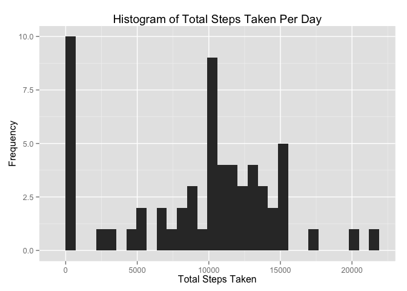

This table shows you the summary of the total, mean and median of steps taken per day:

```r
# calculating the mean and median of the steps taken per day
stepsMean <- summarise(stepsDate, mean(steps, na.rm = TRUE))
stepsMedian <- summarise(stepsDate, median(steps, na.rm = TRUE))
summaryTable <- cbind(stepsSum, stepsMean[, 2], stepsMedian[, 2])
colnames(summaryTable) <- c("Date",
                            "Steps Taken (Total)",
                            "Steps Taken (Mean)",
                            "Steps Taken (Median)"
                            )
print(summaryTable)
```

```
##          Date Steps Taken (Total) Steps Taken (Mean) Steps Taken (Median)
## 1  2012-10-01                   0                NaN                   NA
## 2  2012-10-02                 126          0.4375000                    0
## 3  2012-10-03               11352         39.4166667                    0
## 4  2012-10-04               12116         42.0694444                    0
## 5  2012-10-05               13294         46.1597222                    0
## 6  2012-10-06               15420         53.5416667                    0
## 7  2012-10-07               11015         38.2465278                    0
## 8  2012-10-08                   0                NaN                   NA
## 9  2012-10-09               12811         44.4826389                    0
## 10 2012-10-10                9900         34.3750000                    0
## 11 2012-10-11               10304         35.7777778                    0
## 12 2012-10-12               17382         60.3541667                    0
## 13 2012-10-13               12426         43.1458333                    0
## 14 2012-10-14               15098         52.4236111                    0
```

[output cut: 47 more lines]

## Question 2: What is the average daily activity pattern?

```r
# grouping the data by interval and summarising the resulting data table
stepsInt <- group_by(activity, interval)
stepsIntMean <- summarise(stepsInt, mean(steps, na.rm = TRUE))
colnames(stepsIntMean) <- c("interval", "steps")
```

```r
# plotting time series plot using ggplot2 system
png("plot2.png", width = 480, height = 480, type = "quartz")
h <- ggplot(stepsIntMean, aes(interval, steps))
y <- h + geom_line() +
        labs(title = "Time Series Plot of Interval VS Average Steps Taken") +
        labs(x = "Interval", y = "Average Steps Taken") +
        geom_vline(xintercept = 835, linetype = "longdash")
dev.off()
```

```r
print(y)
```

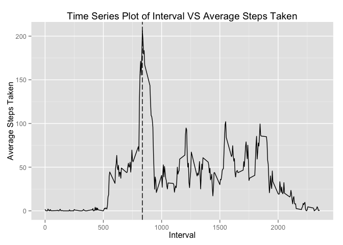

```r
# determining which 5-minute interval has the highest average
stepsMax <- which(stepsIntMean$steps == max(stepsIntMean$steps))
maxSteps <- stepsIntMean$interval[stepsMax]
```

The 5-minute interval with highest number of steps taken is **835** as shown in the plot above.

## Question 3: Imputing missing values

```r
# total number of NAs in the data
totalNA <- sum(!is.na(activity$steps))
```

Since on certain days, total steps taken = 0, we shall use average of steps taken per interval to fill in the NA values. We will select from the mean table the respective values from the intervals.

```r
# converting the activity into data table for merge function later
activityDT <- data.table(activity, key = "interval")
stepsIntMeanDT <- data.table(stepsIntMean, key = "interval")
```

```r
# the following 3 lines convert the NA values to the average values for each
# respective intervals
mergedDT <- activityDT[stepsIntMeanDT]
mergedDT$steps <- as.double(mergedDT$steps)
mergedDT <- mergedDT[is.na(steps), steps := i.steps]
```

```r
# selecting the columns that you want after the conversion
# mergedDT is the new dataset with missing data filled in
mergedDT <- mergedDT[, list(steps, date, interval)]
```

```r
# grouping the data by date and summarising the resulting data table
stepsDate2 <- group_by(mergedDT, date)
stepsSum2 <- summarise(stepsDate2, sum(steps))
colnames(stepsSum2) <- c("date", "steps")
```

```r
# plotting histogram using ggplot2 system
png("plot3.png", width = 480, height = 480, type = "quartz")
i <- ggplot(stepsSum2, aes(x = steps))
x <- i + geom_histogram(binwidth = max(stepsSum2$steps)/30) +
        labs(title = "Histogram of Total Steps Taken Per Day (Filled NAs)") +
        labs(x = "Total Steps Taken", y = "Frequency")
dev.off()
```

```r
print(x)
```

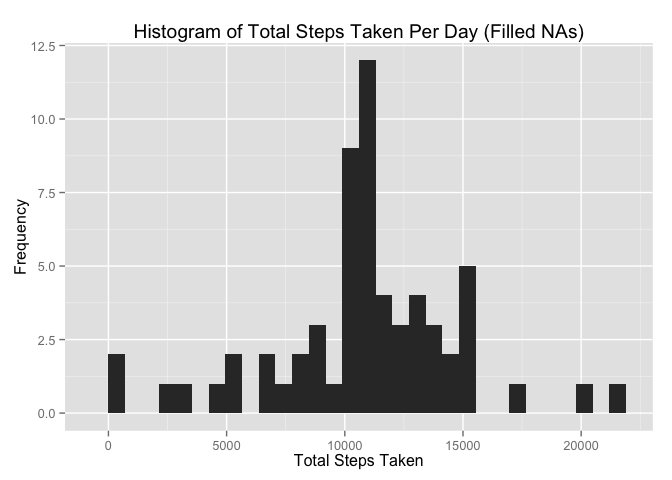

This table shows you the summary of the total, mean and median of steps taken per day after filling in the missing values:

```r
stepsMean2 <- summarise(stepsDate2, mean(steps))
stepsMedian2 <- summarise(stepsDate2, median(steps))
summaryTable2 <- cbind(data.frame(stepsSum2), data.frame(stepsMean2)[, 2],
                       data.frame(stepsMedian2)[, 2])
colnames(summaryTable2) <- c("Date",
                            "Steps Taken (Total)",
                            "Steps Taken (Mean)",
                            "Steps Taken (Median)"
)
print(summaryTable2)
```

```
##          Date Steps Taken (Total) Steps Taken (Mean) Steps Taken (Median)
## 1  2012-10-01            10766.19         37.3825996             34.11321
## 2  2012-10-02              126.00          0.4375000              0.00000
## 3  2012-10-03            11352.00         39.4166667              0.00000
## 4  2012-10-04            12116.00         42.0694444              0.00000
## 5  2012-10-05            13294.00         46.1597222              0.00000
## 6  2012-10-06            15420.00         53.5416667              0.00000
## 7  2012-10-07            11015.00         38.2465278              0.00000
## 8  2012-10-08            10766.19         37.3825996             34.11321
## 9  2012-10-09            12811.00         44.4826389              0.00000
## 10 2012-10-10             9900.00         34.3750000              0.00000
## 11 2012-10-11            10304.00         35.7777778              0.00000
## 12 2012-10-12            17382.00         60.3541667              0.00000
## 13 2012-10-13            12426.00         43.1458333              0.00000
## 14 2012-10-14            15098.00         52.4236111              0.00000
```

[output cut: 47 more lines]

```r
before <- sum(summaryTable[, 2])
after <- sum(summaryTable2[, 2])
after <- as.integer(after)
```

## Question 4: Are there difference in activity patterns between weekdays and weekends?

```r
# converting the dates to weekdays/weekends
activity$date <- as.Date(activity$date, format = "%Y-%m-%d")
weekdays1 <- c("Monday", "Tuesday", "Wednesday", "Thursday", "Friday")
activity$wDay <- factor((weekdays(activity$date) %in% weekdays1),
                        levels = c(FALSE, TRUE),
                        labels = c("Weekend", "Weekday"))

# grouping the data by date and weekday and summarising the resulting data table
activityWday <-group_by(activity, wDay, interval)
wdayMean <- summarise(activityWday, mean(steps, na.rm = TRUE))
colnames(wdayMean) <- c("day", "interval", "steps")
```

```r
# making a panel plot of time series using ggplot2 system
png("plot4.png", width = 480, height = 480, type = "quartz")
wp <- ggplot(wdayMean, aes(interval, steps))
w <- wp + geom_line() + facet_grid(day ~ .) +
        labs(title = "Time Series Plot of Interval VS Average Steps Taken") +
        labs(x = "Interval", y = "Average Steps Taken")
dev.off()
```

```r
print(w)
```

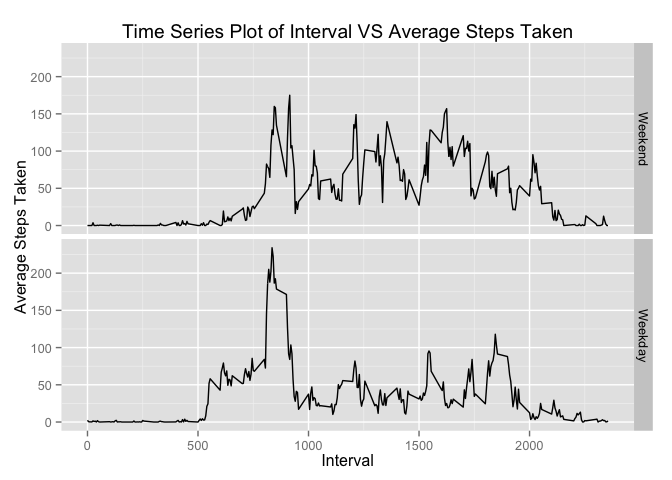

## Thank you and congratulations on reading everything! =)